# Assignment 3

Danny Godbout

July 12, 2016

## Introduction

The purpose of this assignment is to evaluate the effects of fuel type, aspiration, and drive wheels on the price of vehicles in the Automobile Price dataset.

## Normality Tests

After importing and typing the data, we first analyze the normality of the price data using a Shapiro-Wilk’s normality test and visually inspecting with a Q-Q plot. Due to obvious non-normality of the raw price data, the price column is log-transformed and tested for normality as well.

#### Price

The Shapiro-Wilk result of W = 0.8 indicates some skewing, and a p < 0.001 means we reject the null hypothesis that the sample is normally distributed. This conclusion is supported by visual inspection of the Q-Q plot showing deviations from the expected diagonal line at the tails.

```
## auto.data$price
##
##  Shapiro-Wilk normality test
##
## data:  target
## W = 0.79852, p-value = 2.216e-15
```

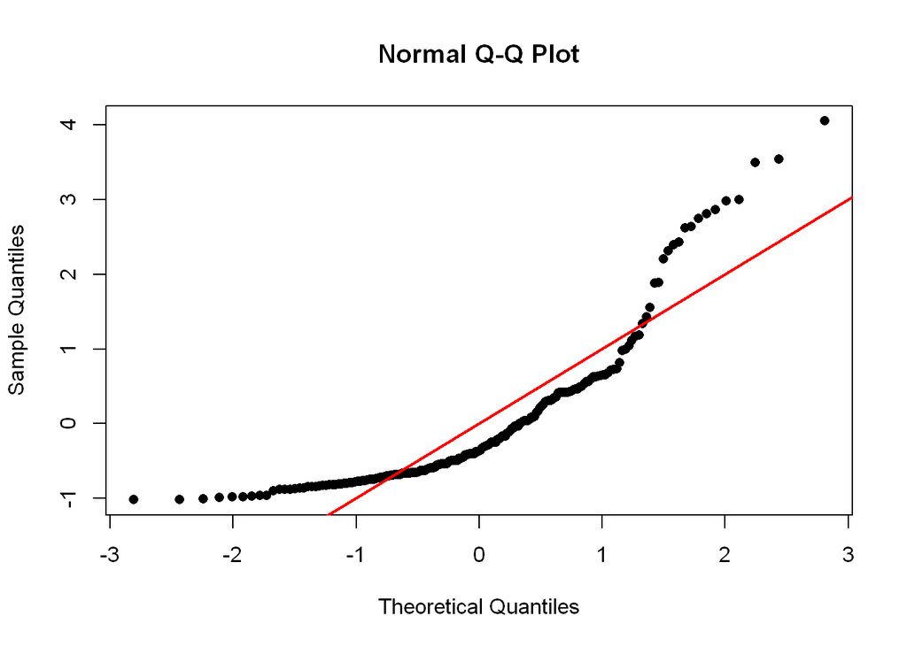

#### Log Price

Transforming the price column with a log-price, we see an improvement in the Shapiro-Wilk W score approaching 1. However, the p-value remains < 0.001 and we must reject the null hypothesis that the sample is normally distributed. The Q-Q plot shows that while the distribution is much improved, there is still some skewing at the tails.

```
## auto.data$log.price
##
##  Shapiro-Wilk normality test
##
## data:  target
## W = 0.949, p-value = 1.432e-06
```

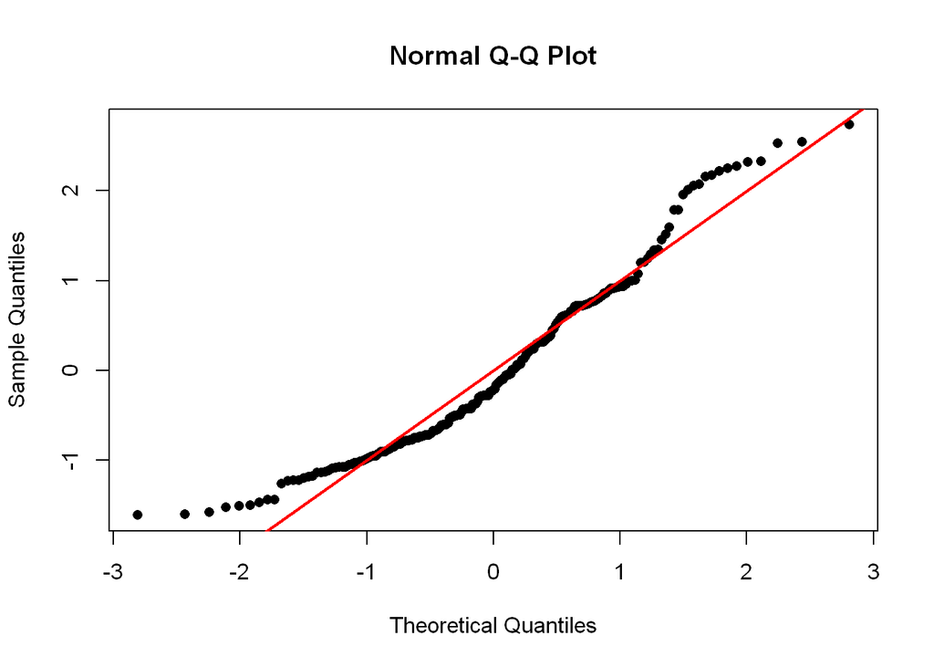

## T-Tests

T-tests were performed on price and log-price, stratified by fuel type (diesel-gas), aspiration (normal-turbo) and drive wheels (rear-front). A Welch t-test was used to compare mean prices between stratification groups. Welch is more robust than a Student t to skewed data. A two-tailed analysis was performed as we simply care about price differences, and not the direction of any difference.

#### Fuel Type

The following hypotheses are formulated for comparison of price/log-price on fuel type $H_0 : \mu_{Diesel} = \mu_{Gas}$ $H_1 : \mu_{Diesel} < \mu_{Gas}$ $H_2 : \mu_{Diesel} > \mu_{Gas}$

Visual inspection of the boxplots of both price and log-price indicate significant overlap of the first through third quartiles. The p-values of the t-tests indicate that we fail to reject the null hypothesis and there is **no significant difference in mean price of diesel and gas cars at the 0.05 level.**

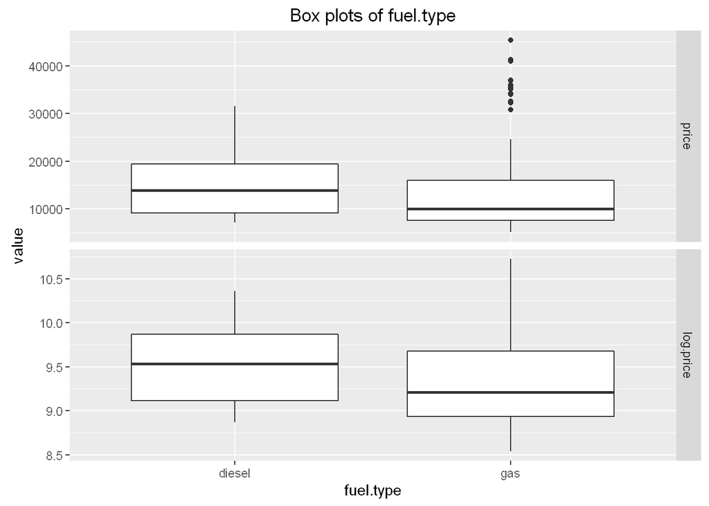

| comparison | p | mean.estimate.diesel | mean.estimate.gas |
| --- | --- | --- | --- |
| price | 0.1241762 | 15838.15 | 12916.41 |
| log.price | 0.0574597 | 14149.30 | 11239.71 |

#### Aspiration

The following hypotheses are formulated for comparison of price/log-price on aspiration $H_0 : \mu_{Std} = \mu_{Turbo}$ $H_1 : \mu_{Std} < \mu_{Turbo}$ $H_2 : \mu_{Std} > \mu_{Turbo}$

The p-values of both price and log-price t-tests indicate that we reject the null hypothesis and there is **significant difference in mean price of normally and turbo aspirated cars at the 0.05 level.** Based on the estimated means of each group, it appears that the price of turbo vehicles is significantly higher than normally aspirated (alternative hypothesis H1).

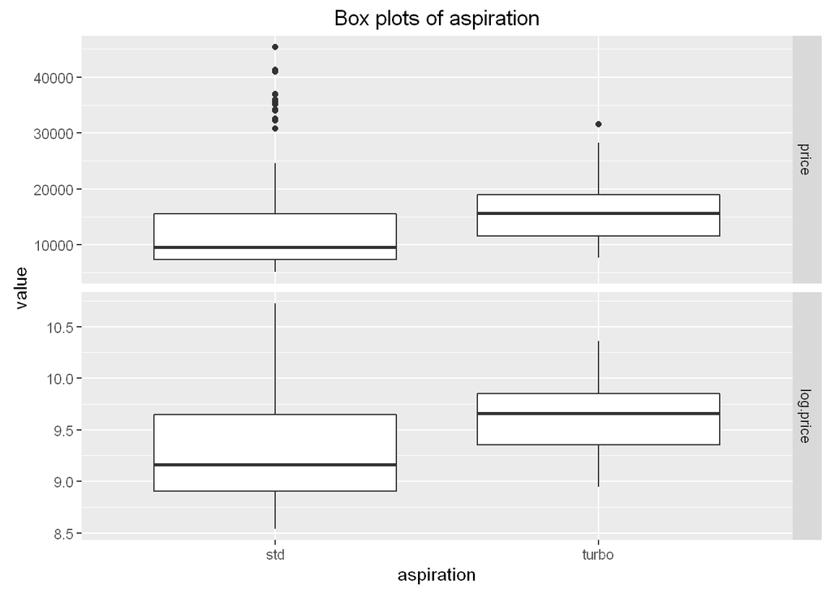

| comparison | p | mean.estimate.std | mean.estimate.turbo |
| --- | --- | --- | --- |
| price | 0.0031352 | 12542.18 | 16254.81 |
| log.price | 0.0000314 | 10828.49 | 15152.67 |

#### Drive wheels

The following hypotheses are formulated for comparison of price/log-price on drive wheels $H_0 : \mu_{Rear} = \mu_{Front}$ $H_1 : \mu_{Rear} < \mu_{Front}$ $H_2 : \mu_{Rear} > \mu_{Front}$

The p-values of both price and log-price t-tests indicate that we reject the null hypothesis and there is **significant difference in mean price of front and rear drive cars at the 0.05 level.** Based on the estimated means of each group, it appears that the price of rear drive vehicles is significantly higher than front drive (alternative hypothesis H2).

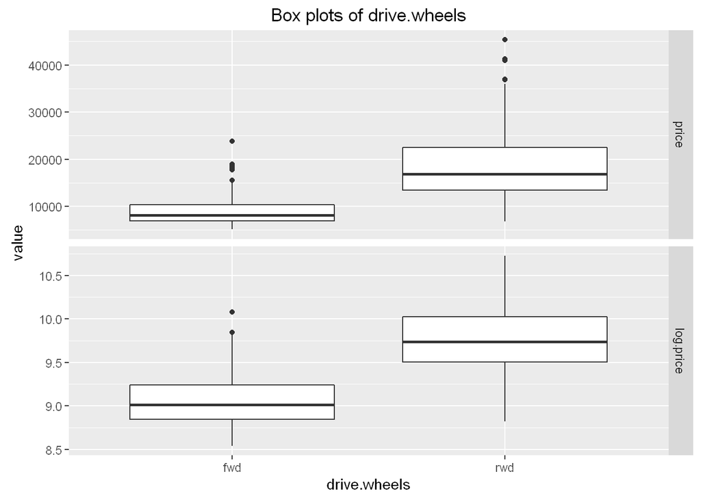

| comparison | p | mean.estimate.fwd | mean.estimate.rwd |
| --- | --- | --- | --- |
| price | 0 | 9244.780 | 19757.61 |
| log.price | 0 | 8757.201 | 17947.30 |

## Source code

```r
#### Load libraries ####

library(dplyr)
library(reshape2)
library(ggplot2)




#### Function definitions ####

f_normality_tests <- function(target) {
  ## This function will perform a Shapiro-Wilk's test and produce a qq-plot
  ## for a target column from a dataframe
  ##
  ## Input args:
  ##    target- dataframe column to be tested
  ## Outputs:
  ##    Prints results of shapiro-wilk's test
  ##    Prints qqplot of target

  print(substitute(target))

  # Perform shapiro-wilk's normality test
  print(shapiro.test(target))

  # Produce qq-plot
  qqnorm(scale(target), pch=16)
  abline(0,1, lwd=2, col="red")

}


f_welch_t_test <- function(data, melt.id) {
  ## This function performs t-tests and produced boxplots on price and log-price of data stratified on a "melt.id".
  ## A Welch's t-test is used due to the following assumptions:
  ##    * Skewness appears in normality test, Welch's is more robust than Student's to skewness
  ##    * Two-tailed test as we are interested in difference in means between two groups, regardless of direction
  ##
  ## Input args:
  ##    data - input dataframe with "price" and "log.price" columns
  ##    melt.id - column name of stratification variable
  ## Outputs:
  ##    Print boxplots of price and logprice data
  ##    t.test.results- table of t.test results for price and logprice

  # Filter input dataframe down to the stratification variable and price/logprice columns, and melt into EAV format
  target.vars <- c("price", "log.price")
  stratified.auto.data <- data %>% melt(id = melt.id, na.rm = TRUE) %>% filter(variable %in% target.vars)
  colnames(stratified.auto.data) <- c("melt.var", "variable", "value")
  stratified.auto.data$value <- as.numeric(stratified.auto.data$value)

  # Perform t-test on price data
  price.data <- stratified.auto.data %>% filter(variable == "price")
  price.t.test <- t.test(value ~ melt.var, data = price.data)

  # Perform t-test on logprice data
  log.price.data <- stratified.auto.data %>% filter(variable == "log.price")
  log.price.t.test <- t.test(value ~ melt.var, data = log.price.data)

  # Generate boxplots for price and logprice data
  p.boxplot <- ggplot(stratified.auto.data, aes(melt.var, value)) +
    geom_boxplot() +
    facet_grid(variable ~ ., scales = "free") +
    labs(title = paste("Box plots of ", melt.id, sep = ""),
         x = melt.id)
  print(p.boxplot)

  # Combine t-test results into a single table
  t.test.results <- data.frame("comparison" = c("price", "log.price"),
                               "t" = c(price.t.test$statistic, log.price.t.test$statistic),
                               "p" = c(price.t.test$p.value, log.price.t.test$p.value),
                               "ci.95.low" = c(price.t.test$conf.int[1], exp(log.price.t.test$conf.int[1])),
                               "ci.95.hi" = c(price.t.test$conf.int[2], exp(log.price.t.test$conf.int[2])),
                               "mean.estimate.A" = c(price.t.test$estimate[1], exp(log.price.t.test$estimate[1])),
                               "mean.estimate.B" = c(price.t.test$estimate[2], exp(log.price.t.test$estimate[2])))

  # Set names on t.test.results to use the melt.id. This can't be done programatically when building the DF, so it's done
  # separately using the colnames function()
  groups <- levels(as.factor(stratified.auto.data$melt.var))

  colnames(t.test.results) <- c("comparison", "t", "p",
                                "ci.95.lo", "ci.95.hi",
                                paste("mean.estimate.", groups[1], sep = ""),
                                paste("mean.estimate.", groups[2], sep = ""))

  # Return results table
  return(t.test.results)
}




#### Load automobile dataset ####

auto.data <- read.csv('Automobile price data _Raw_.csv', stringsAsFactors = FALSE)




#### Select proper columns and set format ####

## Select columns we will use for stratification
auto.data <- auto.data %>% select(price, fuel.type, aspiration, drive.wheels)

## Set types on factor columns
factor.cols <- c("fuel.type", "aspiration", "drive.wheels")
auto.data[, factor.cols] <- lapply(auto.data[factor.cols], as.factor)

## Set types on numeric columns
numeric.cols <- c("price")
auto.data[, numeric.cols] <- lapply(auto.data[numeric.cols], as.numeric)




#### Calculate log-price column ####

auto.data <- auto.data %>% mutate(log.price = log(price))




#### Test price and log-price for normality ####

# Run Shapiro Wilk's test on target columns
f_normality_tests(auto.data$price)

f_normality_tests(auto.data$log.price)




#### Test significance of price stratified on specific features ####

# Perform t-test on fuel type, aspiration, and drive wheels variables
f_welch_t_test(data = auto.data, melt.id = "fuel.type")

f_welch_t_test(data = auto.data, melt.id = "aspiration")

drive.wheels.data <- auto.data %>% filter(drive.wheels != "4wd") %>% droplevels()
f_welch_t_test(data = drive.wheels.data, melt.id = "drive.wheels")
```